# Productivity tools in UNIX

## Terminal

For millenials: that thing that became famous 20 years ago with the movie "The Matrix".

[figure not shown]

## Terminal (real life)

It is a text-only interface to interact with a computer. It receives standard input from a user and returns standard output and standard error.

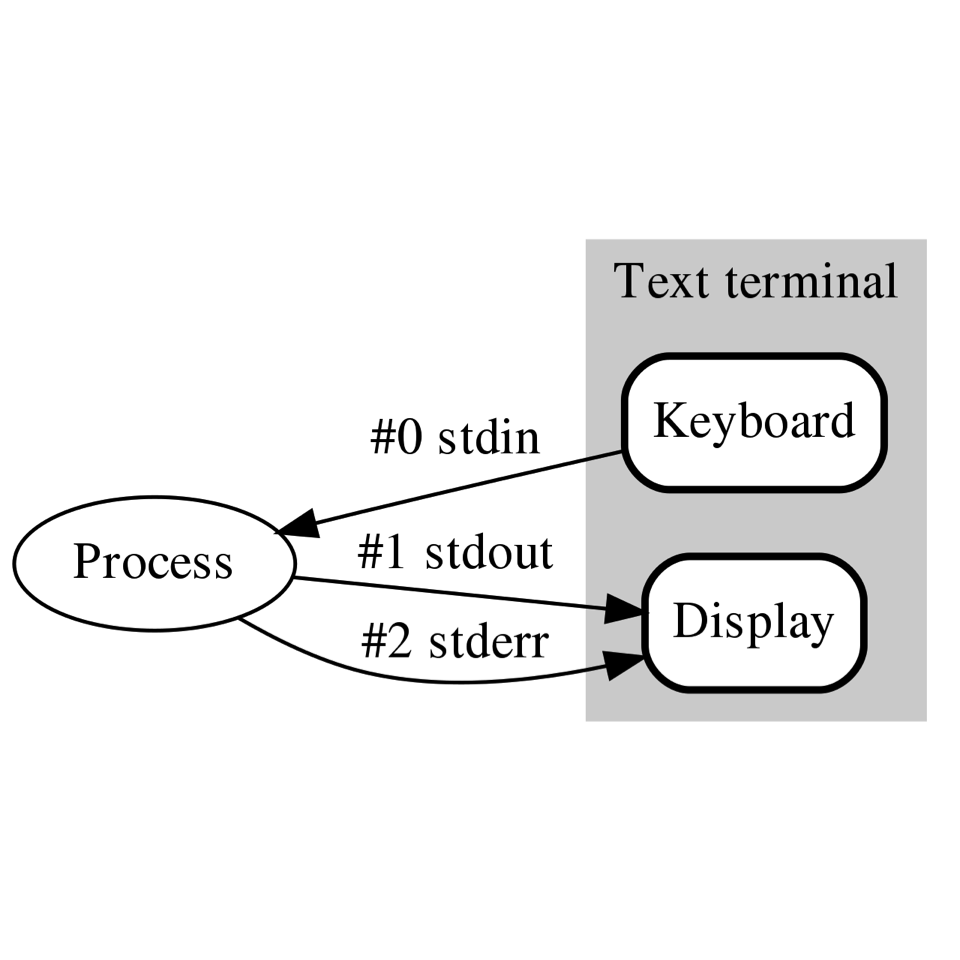

## Opening the terminal (MAC OS)

- Spotlight Search
- Type "terminal" -> Press enter

```bash
echo 'Hello world'
```

## How to find commands?

The best way to find a command is to use Google. It is nothing to be ashamed of, programmers do it all the time. For example, if we forgot the name of the `echo` command, we could google it:

- "How to print output text in the terminal?"

Look at this video: https://www.youtube.com/watch?v=HluANRwPyNo

## Passing parameters and arguments

Typically, linux commands contain three parts: (1) the command, (2) parameters passed via a `-` and (3) the arguments.

```bash
echo -n 'Hello world'
```

In this example, `echo` is the command, `-n` is the parameter and `'Hello world'` is the argument.

## Looking for help

- Option A:

```bash
man echo
```

- Option B:

GOOGLE!!

## The "tab tab tab" and "upper key" tricks

It is actually called autocomplete. It provides all possible options to complete your commands.

```bash
ec
```

If you press the upper key button, it will take you to the last command you used. Try it!

## "Finder" app using the terminal (I)

The print working directory command (`pwd`) returns the "current" location of the file system. By default, the terminal starts in your `home` directory.

```bash
pwd
```

The list files (`ls`) command returns the names of all the files in the current directory:

```bash
ls
```

If we add the `-l` parameter to `ls`, it will provide a long and ordered version of `ls`.

```bash
ls -l
```

## "Finder" app using the terminal (II)

As in the "Finder" app, we can create new directories (i.e. folders) using the `mkdir` command. In general, life will be easier if we avoid special characters, **including spaces**!

```bash
mkdir Newdirectory
```

We can switch between directories using the change directory (`cd`) command.

```bash
cd Newdirectory
```

Note that if you run `cd` without arguments, it will take you back to your home directory.

## Exercise I

What are the meanings of `.`, `..`, and `~`?

*Hint:* Run the `ls` command giving `.`, `..` and `~` as an argument. Alternatively, replace `ls` by `cd` and then run `pwd`.

## Wild cards (I)

```bash
cd ~
cd Newdirectory
touch bob.txt karla.txt kim.txt bib.txt
ls
```

## Wild cards (II)

- `*` represents zero or more characters

```bash
ls k*
```

- `?` represents a single character

```bash
ls ???.txt
```

- `[]` represents a range of characters

```bash
ls b[io]b.txt
```

## Copying files

Let's generate two directories *BNames* and *Knames*, using the `mkdir` command:

```bash
cd ~/Newdirectory
mkdir BNames
mkdir KNames
```

Now we will copy all files starting with a *b* to the directory *BNames* and all the files starting with a *k* to the directory *KNames*:

```bash
cp b* BNames
cp k* KNames
ls -l *Names
```

## Exercise (Moving files)

Using the `mv` command, move the text files that start with b to the directory BNames and the ones that start with k to the directory KNames.

## Removing files (use with caution!)

I won't dare to provide code examples. The syntax is identical to the `cp` and `mv` commands. If you remove a file using the terminal, it won't go to a "Trash" directory, it will be **deleted from memory**!

## Writing results to a file

Using the character `>`, we can direct the standard output to a file. For example, with the command below we can direct the output of `ls -l` to the file *listOfFiles.txt*

```bash
ls -l > listOfFiles.txt
```

We can see the content of text files using `cat`:

```bash
cat listOfFiles.txt
```

## Exercise II

Change directory (`cd`) to `Newdirectory` directory, create a new directory called `FirstExercises` and move all contents into `FirstExercises`.

## Downloading files

There are at least two ways to download files from the internet. One is using the `curl` command:

```bash
curl ftp://ftp.ensemblgenomes.org/pub/release-42/fungi/gtf/saccharomyces_cerevisiae/Saccharomyces_cerevisiae.R64-1-1.42.gtf.gz > Saccharomyces_cerevisiae.R64-1-1.42.gtf.gz
```

In some linux systems, sometimes curl is not installed by default. If this is the case, we could alternatively use the command `wget`:

```bash
wget ftp://ftp.ensemblgenomes.org/pub/release-42/fungi/gtf/saccharomyces_cerevisiae/Saccharomyces_cerevisiae.R64-1-1.42.gtf.gz
```

Let's simplify the name of the annotation file to `annotation.gtf.gz`:

```bash
mv Saccharomyces_cerevisiae.R64-1-1.42.gtf.gz annotation.gtf.gz
```

## Decompressing files

There are several commands to decompress files (`gunzip`, `unzip`, `bzip2`). They are used depending on the algorithm that was used to compress the file, which is typically shown in the file extension. Our annotation file has the termination *gz* and we will use the corresponding command (`gunzip`) to decompress our file:

```bash
gunzip annotation.gtf.gz
```

To re-compress the file, we could use the `gzip` command:

```bash
gzip annotation.gtf
```

And to de-compress it again:

```bash
gunzip annotation.gtf.gz
```

## Exercise (III)

What is the difference in disk space between the compressed and the uncompressed file?

## Viewing large files (I)

As shown before, we could use the `cat` command:

```bash
cat annotation.gtf
```

## Viewing large files (II)

Maybe the `cat` command was not the best idea. Better ideas are to use commands `head`, `tail` and `less`.

`head` will show the first lines of the file:

```bash
head annotation.gtf
```

`tail` will show the last lines of the file:

```bash
tail annotation.gtf
```

`less` will display part of the file, with the possibility of scrolling up and down. Use `q` to exit:

```bash
less annotation.gtf
```

## Matching words and use of pipe

How many lines does the annotation file contain?

```bash
wc -l annotation.gtf
```

Let's suppose that we want to get only the lines of our annotation file containing the **Mito** word. We will use the `grep` command for this:

```bash
grep Mito annotation.gtf
```

How about counting the lines in which the **Mito** word appear? A way to solve this is to pipe (`|`) the result of the `grep` command, and input it to `wc -l`:

```bash
grep Mito annotation.gtf | wc -l
```

## Complex tasks (cut and uniq)

How many chromosomes does the Yeast genome have?

```bash
cut -f1 annotation.gtf | grep -v '#!' | uniq | wc -l
```

## Complex tasks (cut and uniq)

How many times does chromosome "V" appears?

Note that if we use the pattern "V" for `grep`, we will also get other chromosomes that match, including "V", "VI", "IV", and so on. To identify **only** the "V" pattern, we will need to use `^` to specify that the line starts with "V" and `$` to specify that the line finishes "V":

```bash
cut -f1 annotation.gtf | grep '^V$' | wc -l
```

An alternative would be to pass the `-x` command, which instructs `grep` to return only lines where the pattern matches exactly the whole line:

```bash
cut -f1 annotation.gtf | grep -x 'V' | wc -l
```

## Complex tasks (assignments and for loops)

As in every programming language, we can (1) save our results into variables and (2) use `for` loops to iterate over vectors.

The example below, stores the output of the `cut` line into a variable `i`. Then uses a for loop to print each elements of `i`.

```bash
i=`cut -f1 annotation.gtf | grep -v '#!' | uniq`
for x in `echo ${i}`
  do
    echo ${x}
  done
```

## Exercise IV (advanced)

Count the number of lines that each chromosome appears in the file. Hint: combine the code from the two previous slides.